# MATH 2310 Lab 3 - Numerical Summaries & Boxplots

Jakob Balkovec

2024-05-09

# Table of Contents

1. Utility Functions
2. Activity One
3. Activity Two

### Utility Functions

```r
# {
# @brief Creates a summary table of numerical statistics for the given data frame.
#
# @param data_frame_sub: data.frame
#   - The data frame containing the numerical data.
# @return A summary table of mean, standard deviation, and five-number summary.
#
# Table Legend:
#  Mean    ...  -> Mean
#  SD      ...  -> Standard Deviation
#  Min     ...  -> Minimum
#  Q1      ...  -> 1st Quartile
#  Median  ...  -> Median
#  Q3      ...  -> 3rd Quartile
#  Max     ...  -> Maximum
#
# }
create_summary_table <- function(data_frame_sub) {
  mean <- mean(data_frame_sub)
  sd <- sd(data_frame_sub)

  fivenum <- fivenum(data_frame_sub)

  summary_table <- data.frame(
      Mean = round(mean, digits = 2),
      SD = round(sd, digits = 2),
      Min = round(fivenum[1], digits = 2),
      Q1 = round(fivenum[2], digits = 2),
      Median = round(fivenum[3], digits = 2),
      Q3 = round(fivenum[4], digits = 2),
      Max = round(fivenum[5], digits = 2)
  )

  knitr::kable(summary_table, format = "html") %>%
  kable_styling(bootstrap_options = "striped", full_width = TRUE) %>%
  add_header_above(c("Summary" = 2, "Five-Number Summary" = 5))
}
```

```r
# {
# @brief Plots a comparative boxplot of rainfall data by treatment.
#
# @param data_frame_sub: data.frame
#  - The data frame containing the rainfall data.
#
# @param log: bool
#  - indicating whether to plot the log-transformed rainfall data.
# }
plot_rainfall_boxplot <- function(data_frame_sub, log) {

  if(!log) {
    y_label <- "Rainfall"
    title <- "Comparative Boxplot of Rainfall by Treatment"
  } else {
    y_label <- "Log_Rainfall"
    title <- "Comparative Boxplot of Log Rainfall by Treatment"
  }

  ggplot(data_frame_sub, aes(x = Treatment,
                             y = !!rlang::sym(y_label),
                             fill = Treatment)) +
    geom_boxplot(color = "black",
                 alpha = 0.7) +

    scale_fill_manual(values = c("#FF5733", "#33FF57"),
                      name = "Treatment") +

    labs(x = "Treatment",
         y = y_label,
         title = title) +

    theme_minimal() +
    theme(legend.position = "bottom",
          plot.title = element_text(face = "bold",
                                    size = 14,
                                    hjust = 0.5))
}
```

```r
# Read the excel file and define the data as a variable
data_frame <- read_excel("clouds.xlsx")

# Subcategories
seeded <- data_frame$Rainfall[data_frame$Treatment == "Seeded"]
unseeded <- data_frame$Rainfall[data_frame$Treatment == "Unseeded"]

# Log Transformed Data
data_frame$Log_Rainfall <- log(data_frame$Rainfall)
```

## Activity One

##### **[Question A]** - *Put together a summary of the cloud seeding data, including the mean, standard deviation, and five-number summary for each of the two groups (seeded and unseeded clouds).*

###### **[Answer A] - Seeded**

```r
create_summary_table(seeded)
```

| Summary Mean | Summary SD | Five-Number Summary Min | Five-Number Summary Q1 | Five-Number Summary Median | Five-Number Summary Q3 | Five-Number Summary Max |
| --- | --- | --- | --- | --- | --- | --- |
| 441.98 | 650.79 | 4.1 | 92.4 | 221.6 | 430 | 2745.6 |

###### **[Answer A] - Unseeded**

```r
create_summary_table(unseeded)
```

| Summary Mean | Summary SD | Five-Number Summary Min | Five-Number Summary Q1 | Five-Number Summary Median | Five-Number Summary Q3 | Five-Number Summary Max |
| --- | --- | --- | --- | --- | --- | --- |
| 164.59 | 278.43 | 1 | 24.4 | 44.2 | 163 | 1202.6 |

##### **[Question A]** *Of these numerical summaries, which are the most appropriate to use in describing this data? Why?*

I think it’s challenging to determine which summary is the most appropriate since all of them provide valuable insights into the provided data.

- **Mean**: It gives us the average rainfall across both treatment groups, which is useful but may be skewed by outliers (as evident in the dataset).
- **Standard Deviation**: The standard deviation seems quite high right off the bat. This suggests considerable variability in the dataset and a wide range of values from the average.
- **Five-Number Summary**: This one might seem the most useful as it provides a decent amount of information about the data. The **median** (Q2) gives us an idea of the middle point of the dataset, while the quartiles (**Q1** and **Q3**) provide insights into the spread of the data. The **minimum** and **maximum** represent the range of rainfall observations, indicating potential outliers at both extremes.

To conclude, I believe the **Five-Number Summary** is the most appropriate summary to describe the clouds dataset.

##### **[Question B]** - *Construct comparative boxplots for the cloud seeding data.*

###### **[Answer B] - Boxplot**

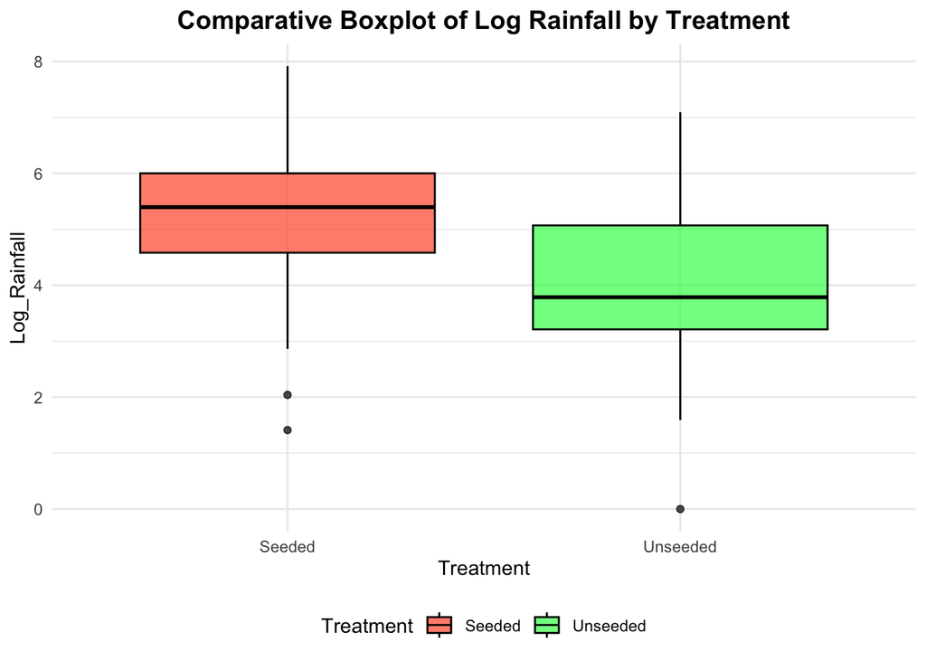

```r
# Create a boxplot
plot_rainfall_boxplot(data_frame, log=TRUE)
```

## Activity Two

##### **[Question A]** *Put together a summary of the log transformed cloud seeding data, including the mean, standard deviation, and five-number summary for each of the two groups (seeded and unseeded clouds).*

```r
log_seeded <- data_frame$Log_Rainfall[data_frame$Treatment == "Seeded"]
log_unseeded <- data_frame$Log_Rainfall[data_frame$Treatment == "Unseeded"]
```

###### **[Answer A] - Log Seeded**

```r
create_summary_table(log_seeded)
```

| Summary Mean | Summary SD | Five-Number Summary Min | Five-Number Summary Q1 | Five-Number Summary Median | Five-Number Summary Q3 | Five-Number Summary Max |
| --- | --- | --- | --- | --- | --- | --- |
| 5.13 | 1.6 | 1.41 | 4.53 | 5.4 | 6.06 | 7.92 |

###### **[Answer A] - Log Unseeded**

```r
create_summary_table(log_unseeded)
```

| Summary Mean | Summary SD | Five-Number Summary Min | Five-Number Summary Q1 | Five-Number Summary Median | Five-Number Summary Q3 | Five-Number Summary Max |
| --- | --- | --- | --- | --- | --- | --- |
| 3.99 | 1.64 | 0 | 3.19 | 3.79 | 5.09 | 7.09 |

##### **[Question A]** *Of these numerical summaries, which are the most appropriate to use in describing this data? Why?*

###### **[Answer A]**

- **Mean**: The mean of the log-transformed data gives us a measure of central tendency, indicating the average value of the data points on the log scale.
- **Standard Deviation**: The standard deviation of the log-transformed data measures the spread or variability of the data points around the mean on the log scale. It tells us how much the data deviates from the mean value.
- **Five-Number Summary**: This one might not be the most useful as we can’t rely on the minimum or the maximum. That doesn’t necessarily mean the other values in the Five-Number Summary are useless. We can focus on **Q1**, **Median (Q2)**, and **Q3**. These quartiles provide us with information about the spread and distribution of the data across different percentiles on a log scale.

Again, to conclude, I believe a combination of the **Mean**, **SD**, and the **Five-Number Summary (excluding Min and Max)** is the most appropriate summary to describe the clouds dataset.

**Jakob Balkovec**